# california_housing_regression

Diewo Lah

2024-10-13

```r
library(tidyverse) #manipuler et visualiser des données
```

```r
library(corrplot) #visualiser les corrélations entre les variables
```

### Import du dataset

```r
df <- read.csv("california_housing.csv")
head(df)
```

```
##   longitude latitude housing_median_age total_rooms total_bedrooms population
## 1   -122.23    37.88                 41         880            129        322
## 2   -122.22    37.86                 21        7099           1106       2401
## 3   -122.24    37.85                 52        1467            190        496
## 4   -122.25    37.85                 52        1274            235        558
## 5   -122.25    37.85                 52        1627            280        565
## 6   -122.25    37.85                 52         919            213        413
##   households median_income median_house_value ocean_proximity
## 1        126        8.3252             452600        NEAR BAY
## 2       1138        8.3014             358500        NEAR BAY
## 3        177        7.2574             352100        NEAR BAY
## 4        219        5.6431             341300        NEAR BAY
## 5        259        3.8462             342200        NEAR BAY
## 6        193        4.0368             269700        NEAR BAY
```

```r
str(df)
```

```
## 'data.frame':    20640 obs. of  10 variables:
##  $ longitude         : num  -122 -122 -122 -122 -122 ...
##  $ latitude          : num  37.9 37.9 37.9 37.9 37.9 ...
##  $ housing_median_age: num  41 21 52 52 52 52 52 52 42 52 ...
##  $ total_rooms       : num  880 7099 1467 1274 1627 ...
##  $ total_bedrooms    : num  129 1106 190 235 280 ...
##  $ population        : num  322 2401 496 558 565 ...
##  $ households        : num  126 1138 177 219 259 ...
##  $ median_income     : num  8.33 8.3 7.26 5.64 3.85 ...
##  $ median_house_value: num  452600 358500 352100 341300 342200 ...
##  $ ocean_proximity   : chr  "NEAR BAY" "NEAR BAY" "NEAR BAY" "NEAR BAY" ...
```

```r
summary(df)
```

```
##    longitude         latitude     housing_median_age  total_rooms
##  Min.   :-124.3   Min.   :32.54   Min.   : 1.00      Min.   :    2
##  1st Qu.:-121.8   1st Qu.:33.93   1st Qu.:18.00      1st Qu.: 1448
##  Median :-118.5   Median :34.26   Median :29.00      Median : 2127
##  Mean   :-119.6   Mean   :35.63   Mean   :28.64      Mean   : 2636
##  3rd Qu.:-118.0   3rd Qu.:37.71   3rd Qu.:37.00      3rd Qu.: 3148
##  Max.   :-114.3   Max.   :41.95   Max.   :52.00      Max.   :39320
##
##  total_bedrooms     population      households     median_income
##  Min.   :   1.0   Min.   :    3   Min.   :   1.0   Min.   : 0.4999
##  1st Qu.: 296.0   1st Qu.:  787   1st Qu.: 280.0   1st Qu.: 2.5634
##  Median : 435.0   Median : 1166   Median : 409.0   Median : 3.5348
##  Mean   : 537.9   Mean   : 1425   Mean   : 499.5   Mean   : 3.8707
##  3rd Qu.: 647.0   3rd Qu.: 1725   3rd Qu.: 605.0   3rd Qu.: 4.7432
##  Max.   :6445.0   Max.   :35682   Max.   :6082.0   Max.   :15.0001
##  NA's   :207
##  median_house_value ocean_proximity
##  Min.   : 14999     Length:20640
##  1st Qu.:119600     Class :character
##  Median :179700     Mode  :character
##  Mean   :206856
##  3rd Qu.:264725
##  Max.   :500001
##
```

**Interprétation:**

Le dataset contient des variables quantitatives et qualitatives. La variable cible est **median_house_value** (valeur médiane des maisons).

### Vérification des valeurs manquantes

```r
colSums(is.na(df))
```

```
##          longitude           latitude housing_median_age        total_rooms
##                  0                  0                  0                  0
##     total_bedrooms         population         households      median_income
##                207                  0                  0                  0
## median_house_value    ocean_proximity
##                  0                  0
```

**Interprétation:**

La variable total_bedrooms contient 207 valeurs manquantes, tandis que toutes les autres variables sont complètes. Ces valeurs manquantes seront traitées lors de la régression linéaire, les observations incomplètes (207 lignes) seront automatiquement supprimées par la fonction `lm()`.

### Analyse exploratoire (EDA):

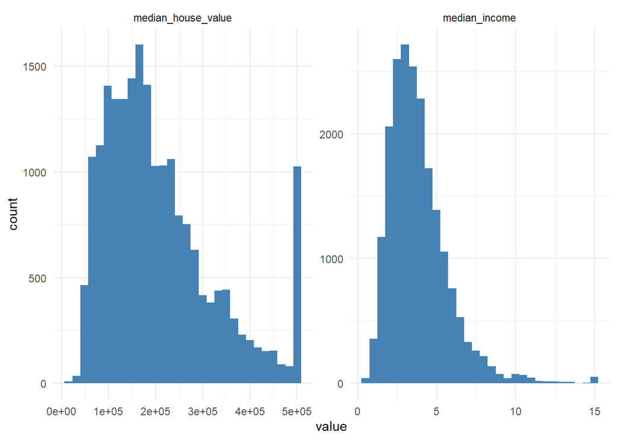

```r
df %>%
  select(median_house_value, median_income) %>%
  pivot_longer(cols = everything()) %>%
  ggplot(aes(value)) +
  geom_histogram(bins = 30, fill = "steelblue") +
  facet_wrap(~name, scales = "free") +
  theme_minimal()
```

**Interprétation:**

Les histogrammes montrent que **median_income** présente une distribution légèrement asymétrique, ce qui peut influencer la relation avec le prix et **median_house_value** est également asymétrique avec quelques valeurs très élevées (outliers).

### Corrélation:

```r
numeric_df <- df %>% select(where(is.numeric))
corr_matrix <- cor(numeric_df)
corr_matrix
```

```
##                      longitude    latitude housing_median_age total_rooms
## longitude           1.00000000 -0.92466443        -0.10819681  0.04456798
## latitude           -0.92466443  1.00000000         0.01117267 -0.03609960
## housing_median_age -0.10819681  0.01117267         1.00000000 -0.36126220
## total_rooms         0.04456798 -0.03609960        -0.36126220  1.00000000
## total_bedrooms              NA          NA                 NA          NA
## population          0.09977322 -0.10878475        -0.29624424  0.85712597
## households          0.05531009 -0.07103543        -0.30291601  0.91848449
## median_income      -0.01517587 -0.07980913        -0.11903399  0.19804965
## median_house_value -0.04596662 -0.14416028         0.10562341  0.13415311
##                    total_bedrooms   population  households median_income
## longitude                      NA  0.099773223  0.05531009  -0.015175865
## latitude                       NA -0.108784747 -0.07103543  -0.079809127
## housing_median_age             NA -0.296244240 -0.30291601  -0.119033990
## total_rooms                    NA  0.857125973  0.91848449   0.198049645
## total_bedrooms                  1           NA          NA            NA
## population                     NA  1.000000000  0.90722227   0.004834346
## households                     NA  0.907222266  1.00000000   0.013033052
## median_income                  NA  0.004834346  0.01303305   1.000000000
## median_house_value             NA -0.024649679  0.06584265   0.688075208
##                    median_house_value
## longitude                 -0.04596662
## latitude                  -0.14416028
## housing_median_age         0.10562341
## total_rooms                0.13415311
## total_bedrooms                     NA
## population                -0.02464968
## households                 0.06584265
## median_income              0.68807521
## median_house_value         1.00000000
```

**Interprétation:**

La matrice de corrélation montre que le revenu médian (**median_income**) est la variable la plus fortement associée au prix des maisons (**r ≈ 0.69**). Les variables décrivant la taille et la densité des foyers (**total_rooms, households, population**) sont fortement corrélées entre elles, indiquant une possible multicolinéarité, mais leur lien direct avec le prix reste faible. Les autres variables, comme la localisation (**longitude, latitude**) et l’âge des maisons (**housing_median_age**), apportent un complément d’information limité.

### Nuage de points clé:

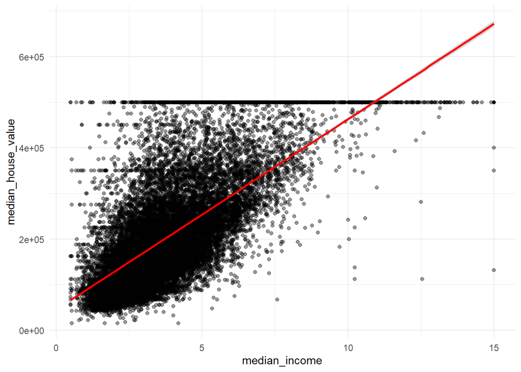

```r
ggplot(df, aes(median_income, median_house_value)) +
  geom_point(alpha = 0.4) +
  geom_smooth(method = "lm", color = "red") +
  theme_minimal()
```

**Interprétation:**

On observe une relation positive entre le revenu médian et le prix des maisons, justifiant l’utilisation d’un modèle de régression linéaire.

### Modèle de régression linéaire

```r
model <- lm(median_house_value ~ ., data = df)
summary(model)
```

```
##
## Call:
## lm(formula = median_house_value ~ ., data = df)
##
## Residuals:
##     Min      1Q  Median      3Q     Max
## -556980  -42683  -10497   28765  779052
##
## Coefficients:
##                             Estimate Std. Error t value Pr(>|t|)
## (Intercept)               -2.270e+06  8.801e+04 -25.791  < 2e-16 ***
## longitude                 -2.681e+04  1.020e+03 -26.296  < 2e-16 ***
## latitude                  -2.548e+04  1.005e+03 -25.363  < 2e-16 ***
## housing_median_age         1.073e+03  4.389e+01  24.439  < 2e-16 ***
## total_rooms               -6.193e+00  7.915e-01  -7.825 5.32e-15 ***
## total_bedrooms             1.006e+02  6.869e+00  14.640  < 2e-16 ***
## population                -3.797e+01  1.076e+00 -35.282  < 2e-16 ***
## households                 4.962e+01  7.451e+00   6.659 2.83e-11 ***
## median_income              3.926e+04  3.380e+02 116.151  < 2e-16 ***
## ocean_proximityINLAND     -3.928e+04  1.744e+03 -22.522  < 2e-16 ***
## ocean_proximityISLAND      1.529e+05  3.074e+04   4.974 6.62e-07 ***
## ocean_proximityNEAR BAY   -3.954e+03  1.913e+03  -2.067  0.03879 *
## ocean_proximityNEAR OCEAN  4.278e+03  1.570e+03   2.726  0.00642 **
## ---
## Signif. codes:  0 '***' 0.001 '**' 0.01 '*' 0.05 '.' 0.1 ' ' 1
##
## Residual standard error: 68660 on 20420 degrees of freedom
##   (207 observations effacées parce que manquantes)
## Multiple R-squared:  0.6465, Adjusted R-squared:  0.6463
## F-statistic:  3112 on 12 and 20420 DF,  p-value: < 2.2e-16
```

**Interprétation:**

Le modèle prédit la valeur médiane des maisons (**median_house_value**) à partir de l’ensemble des variables explicatives.  
Les coefficients représentent l’effet de chaque variable sur le prix, **toutes choses étant égales par ailleurs**.

- **median_income (revenu médian)** a l’impact positif le plus important (~39 260), indiquant que les maisons situées dans des zones à revenu élevé ont une valeur nettement plus élevée.
- **population**, **longitude** et **latitude** ont un effet négatif sur le prix des maisons.
- Les caractéristiques des logements (**housing_median_age**, **total_rooms**, **total_bedrooms**, **households**) influencent également significativement la valeur des biens.
- La variable **ocean_proximity** joue un rôle important : certaines catégories augmentent la valeur des maisons (**ISLAND**, **NEAR OCEAN**), tandis que d’autres la diminuent (**INLAND**, **NEAR BAY**).

Le **R² multiple (0.6465)** indique qu’environ **65 % de la variance** des prix est expliquée par le modèle.  
La statistique de Fisher (F-test) et les p-values confirment que le modèle est **globalement significatif**.

Globalement, le **revenu médian** et les **caractéristiques des logements** sont les variables les plus discriminantes pour prédire le prix des maisons, tandis que la **localisation géographique** et la **proximité de l’océan** apportent une information complémentaire.

### Tests d’hypothèses

**H₀ :** median_income = 0 → Le revenu médian n’influence pas le prix des maisons.

**H₁ :** median_income ≠ 0 → Le revenu médian influence le prix des maisons.

**Interprétation**

La p-value associée est très faible (<2e-16) → rejet de H₀.

median_income influence significativement le prix.

Le F-test global confirme que le modèle explique la variable cible de manière significative.

### Analyse des résidus (Résidus vs valeurs ajustées)

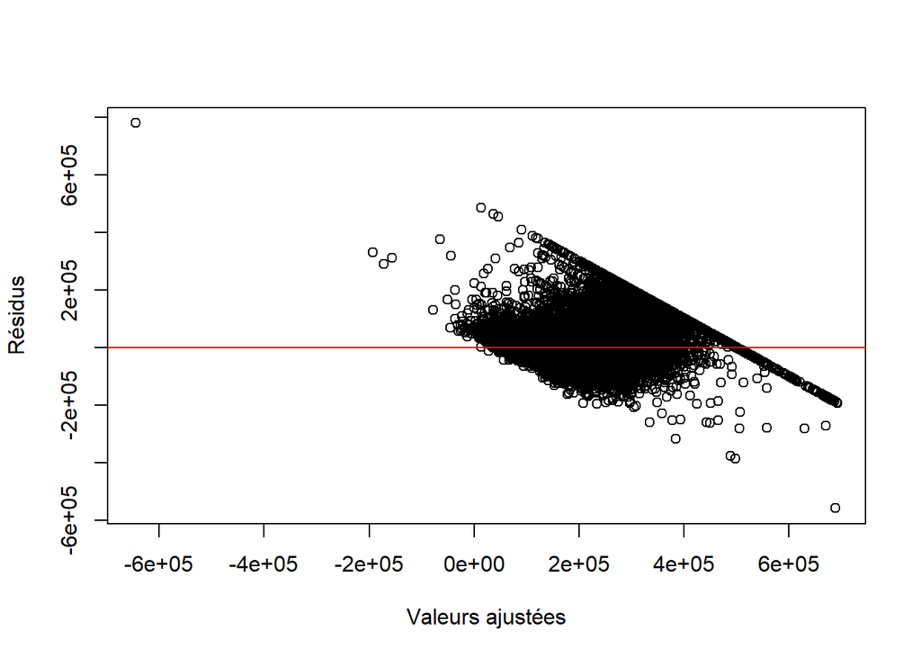

```r
plot(model$fitted.values, model$residuals,
     xlab = "Valeurs ajustées",
     ylab = "Résidus")
abline(h = 0, col = "red")
```

### Normalité des résidus

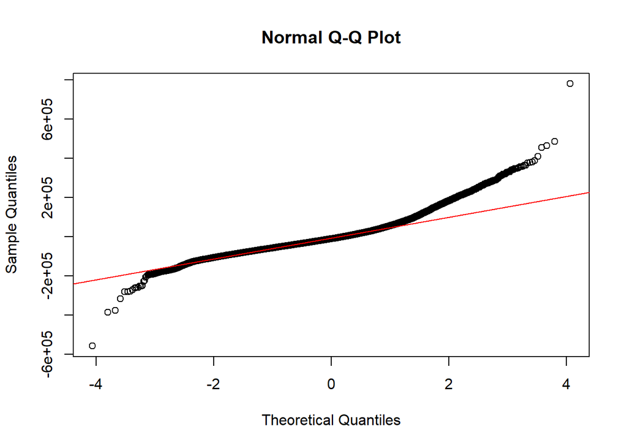

```r
qqnorm(model$residuals)
qqline(model$residuals, col = "red")
```

### Conclusion

L’analyse du dataset California Housing montre que le revenu médian (**median_income**) est le facteur le plus déterminant pour prédire le prix des maisons. Les caractéristiques des logements, telles que la taille des maisons, le nombre de chambres (**total_rooms**) et le nombre de foyers (**households**), ont également un impact significatif sur la valeur des biens.

Ce projet illustre l’usage pratique de la régression linéaire, des tests d’hypothèses et de l’analyse des résidus, offrant un exemple concret de modélisation statistique interprétable, essentiel en data science et intelligence artificielle.